# trying_glm

Trying same with all data (trying to see if this is caused by lack of data).

```r
#Plotting all useful data we have
# Reading the data from excel (time in minutes AND PROBABILITIES IN DECIMAL NUMBER)
df <- read_excel("C:\\Projektit\\whole_blood_research\\excel\\Emergencyprocess_PHBT_splines.xlsx", sheet = "Sheet1")
all_data <- filter(df, products == "O-negative PRBCs" | products == "LTOWB" | products == "plasma and/or RBCs")
print(all_data)
```

```
## # A tibble: 17 × 10
##    Article      `Link to source` products  time mortality_perce… mortality n_tot
##    <chr>        <chr>            <chr>    <dbl>            <dbl>     <dbl> <dbl>
##  1 Civilian pr… https://onlinel… O-negat…  1440             16.1     0.161    56
##  2 <NA>         <NA>             O-negat… 10080             21.4     0.214    56
##  3 <NA>         <NA>             O-negat… 43200             21.4     0.214    56
##  4 Pre-hospita… https://www.ncb… plasma …   360             13.3     0.133    75
##  5 <NA>         <NA>             plasma …  1440             16       0.16     75
##  6 Mortality o… https://www.ncb… O-negat…   360             10       0.1      92
##  7 <NA>         <NA>             O-negat… 40320             26       0.26     78
##  8 Multicenter… https://www.ncb… plasma …   180             16.2     0.162   142
##  9 <NA>         <NA>             plasma …  1440             19       0.19    142
## 10 <NA>         <NA>             plasma … 43200             25.4     0.254   142
## 11 Prehospital… https://pubmed.… LTOWB      360             16.8     0.168   107
## 12 <NA>         <NA>             LTOWB     1440             22.4     0.224   107
## 13 Clinical ou… https://pubmed.… LTOWB      360              3       0.03    135
## 14 <NA>         <NA>             LTOWB     1440              8.9     0.089   135
## 15 Injured rec… https://pubmed.… LTOWB      360              4.4     0.044    92
## 16 <NA>         <NA>             LTOWB     1440             14.1     0.141    92
## 17 <NA>         <NA>             LTOWB    43200             34.8     0.348    92
## # … with 3 more variables: n_dead <dbl>, n_survived <dbl>, ArticleAbbr <chr>
```

```r
# ggplot doesn't understand the gamma link log so not drawing the code below
#ggplot(data = all_data, aes(x = time, y = mortality))+
  #geom_point()+
  #geom_smooth(method = "glm", formula = y~(x), se = FALSE, family = Gamma(link="log"))
```

Then plotting with all data in excel:

```r
p <- glm(mortality ~ time, data = all_data, family = Gamma(link = "log"))
p
```

```
##
## Call:  glm(formula = mortality ~ time, family = Gamma(link = "log"),
##     data = all_data)
##
## Coefficients:
## (Intercept)         time
##  -2.010e+00    1.704e-05
##
## Degrees of Freedom: 16 Total (i.e. Null);  15 Residual
## Null Deviance:       4.986
## Residual Deviance: 3.354     AIC: -38
```

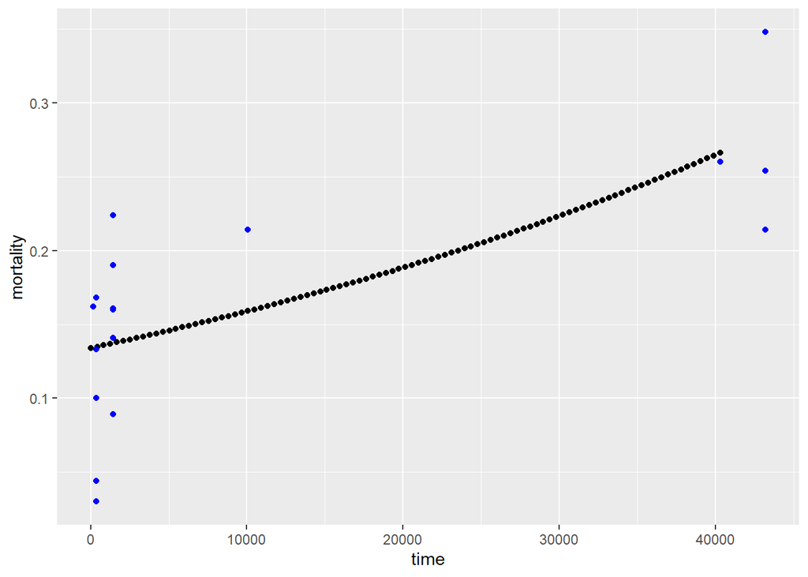

```r
# Making timepoints
variable_time <- data.frame(time=seq(0, 40500, by=420))
tmp <- predict(object = p, newdata = variable_time, type="response")

simulation.data <- data.frame(time = variable_time, mortality = tmp)
ggplot(simulation.data, aes(x = time, y = mortality))+
  geom_point() + geom_point(data = all_data, color = "blue")
```

Didn’t solve the problem. Checking also if adding interaction with articles would change anything.

```r
p <- glm(mortality ~ time*ArticleAbbr, data = all_data, family = Gamma(link = "log"))
p
```

```
##
## Call:  glm(formula = mortality ~ time * ArticleAbbr, family = Gamma(link = "log"),
##     data = all_data)
##
## Coefficients:
##                    (Intercept)                            time
##                     -1.880e+00                       2.664e-04
##      ArticleAbbrCassignol 2020          ArticleAbbrGriggs 2018
##                      1.616e-01                      -4.315e-01
##      ArticleAbbrHenriksen 2016         ArticleAbbrHolcomb 2018
##                     -1.993e-01                       1.338e-01
##        ArticleAbbrSeheult 2018           ArticleAbbrYazer 2021
##                     -1.989e+00                      -5.452e-01
## time:ArticleAbbrCassignol 2020     time:ArticleAbbrGriggs 2018
##                     -2.616e-04                      -2.425e-04
## time:ArticleAbbrHenriksen 2016    time:ArticleAbbrHolcomb 2018
##                     -9.524e-05                      -2.576e-04
##   time:ArticleAbbrSeheult 2018      time:ArticleAbbrYazer 2021
##                      7.405e-04                      -2.344e-04
##
## Degrees of Freedom: 16 Total (i.e. Null);  3 Residual
## Null Deviance:       4.986
## Residual Deviance: 0.6492    AIC: -42.37
```

AIC is getting smaller, which is a nice thing. Trying to plot with this interaction:

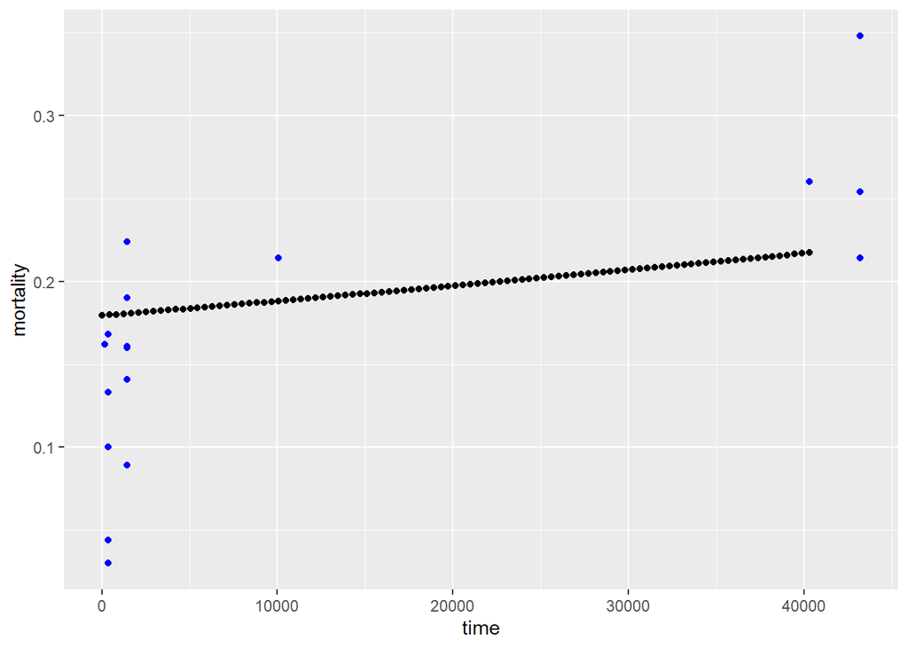

```r
# Making timepoints
variable_time <- data.frame(time=seq(0, 40500, by=420), ArticleAbbr=rep("Cassignol 2020",length(tmp)))
tmp <- predict(object = p, newdata = variable_time, type="response")

simulation.data <- data.frame(time = variable_time$time, mortality = tmp)
ggplot(simulation.data, aes(x = time, y = mortality))+
  geom_point() + geom_point(data = all_data, color = "blue")
```

The curve just gets slighter. This is clearly not working. Simulating more points to see what happens to the curve when the time goes by.

```r
p <- glm(mortality ~ time, data = all_data, family = Gamma(link = "log"))
p
```

```
##
## Call:  glm(formula = mortality ~ time, family = Gamma(link = "log"),
##     data = all_data)
##
## Coefficients:
## (Intercept)         time
##  -2.010e+00    1.704e-05
##
## Degrees of Freedom: 16 Total (i.e. Null);  15 Residual
## Null Deviance:       4.986
## Residual Deviance: 3.354     AIC: -38
```

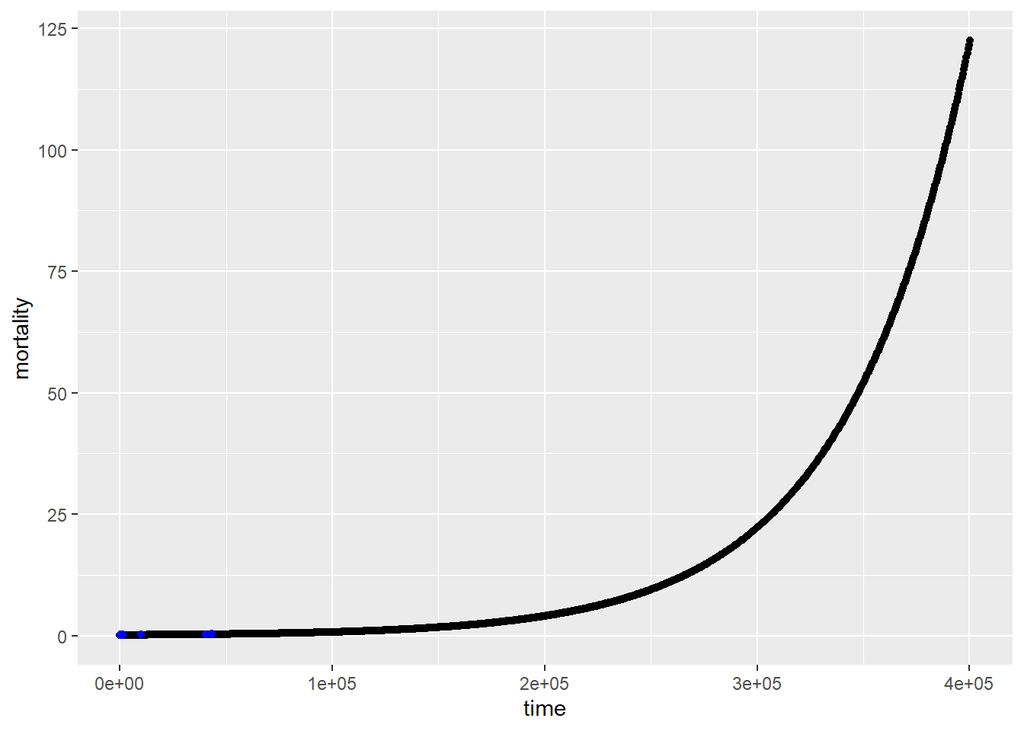

```r
# Making timepoints
variable_time <- data.frame(time=seq(0, 400500, by=420))
tmp <- predict(object = p, newdata = variable_time, type="response")

simulation.data <- data.frame(time = variable_time, mortality = tmp)
ggplot(simulation.data, aes(x = time, y = mortality))+
  geom_point() + geom_point(data = all_data, color = "blue")
```

Well it is clearly wrong way round. This problem remains unsolved and has to be rethought in the fall. Also checked how the suspicious model y ~ log(x) works in the long run:

```r
p <- glm(mortality ~ log(time), data = all_data, family = Gamma(link = "log"))
p
```

```
##
## Call:  glm(formula = mortality ~ log(time), family = Gamma(link = "log"),
##     data = all_data)
##
## Coefficients:
## (Intercept)    log(time)
##     -3.1822       0.1767
##
## Degrees of Freedom: 16 Total (i.e. Null);  15 Residual
## Null Deviance:       4.986
## Residual Deviance: 2.983     AIC: -40.05
```

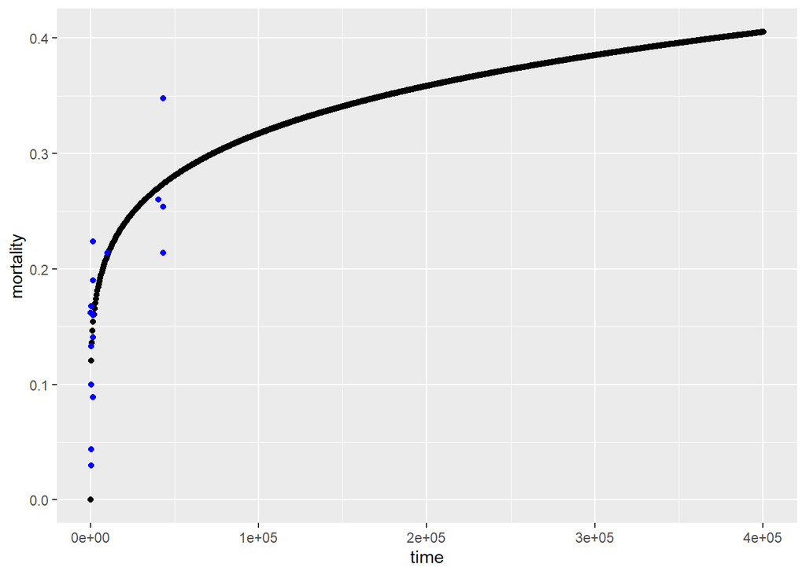

```r
# Making timepoints
variable_time <- data.frame(time=seq(0, 400500, by=420))
tmp <- predict(object = p, newdata = variable_time, type="response")

simulation.data <- data.frame(time = variable_time, mortality = tmp)
ggplot(simulation.data, aes(x = time, y = mortality))+
  geom_point() + geom_point(data = all_data, color = "blue")
```

Seems more reasonable than the other one but as said before, I don’t know if this is okay to do like this or how this is interpreted…